# Case Study 1 : Apply Kmeans clustering to divide the customers into various clusters based on their brand loyalty score and price sensitivity score

Suppose, Amazon wants to divide their customers on the basis of Brand and price of the product they purchase. They want to know how many prefers Brand and how many prefers Price. So that they will offer thier product to the respective types of customer accordingly.

Some customers prefers Branded product without giving importance to its price. Some customers prefer Cheap priced products without giving importance to its brand. Some customers gives importance to both Price and brand of product and then proceed purchasing.

customers who gives importance to price are : Price sensitive customers who gives importance to Brand are : Loyal to Brand

In this dataset,we have customer's previous Price sensitivity score and Brand loyalty Score.

Now We can see that we have brand_loyality_score and price_sensitivity_score which we can take as our feature variable. But we dont have label variable. So this is problem of unsupervised ML algorithm. Thats why we are using K-means in this case.

```python
import pandas as pd
import numpy as np
import matplotlib.pyplot as plt
%matplotlib inline
```

Dataset provided in market_segmentation.csv file contains information about customer. So read the dataset

# 1) Acquire the Data

```python
df = pd.read_csv('marketing_segmentation.csv')
```

```python
df.head()
```

|  | brand_loyality_score | price_sensitivity_score |
| --- | --- | --- |
| 0 | 9.310463 | 5.356477 |
| 1 | 1.887756 | 7.301291 |
| 2 | 9.554102 | 5.339255 |
| 3 | 1.239190 | 7.775585 |
| 4 | 4.042612 | 6.993620 |

```python
df.shape
```

```
(150, 2)
```

```python
df.describe()
```

|  | brand_loyality_score | price_sensitivity_score |
| --- | --- | --- |
| count | 150.000000 | 150.000000 |
| mean | 4.960049 | 6.435248 |
| std | 3.011512 | 0.944013 |
| min | 0.578259 | 4.246792 |
| 25% | 1.889442 | 5.637454 |
| 50% | 4.368651 | 6.565923 |
| 75% | 8.570695 | 7.146110 |
| max | 9.742813 | 8.363148 |

Apply feature scaling by standardizing the data.

# 2) Preprocess the Data

```python
from sklearn.preprocessing import StandardScaler
```

Every sklearn's transform's fit() just calculates the parameters (e.g. μ and σ in case of StandardScaler) and saves them as an internal objects state. Afterwards, you can call its transform() method to apply the transformation to a particular set of examples.

fit_transform() joins these two steps and is used for the initial fitting of parameters on the training set x, but it also returns a transformed x′. Internally, it just calls first fit() and then transform() on the same data.

```python
sc = StandardScaler()
```

```python
df_scaled = sc.fit_transform(df)
```

```python
df_scaled
```

[output not shown]

[output cut: 95 more lines]

```
       [-1.25999718,  1.05359644],
       [ 1.37054054, -1.58283029],
       [ 1.06387809, -0.72744059],
       [ 0.03104973,  1.28569879],
       [-0.35633924,  0.47182742],
       [ 1.47812382, -1.38265166],
       [-0.46915527,  0.71283655],
       [ 1.36592195, -1.78350551],
       [-1.11802484,  0.81443579],
       [ 1.22708171, -0.77910403],
       [ 0.15900706, -0.42106456],
       [ 1.41000058, -1.82145848],
       [ 1.31703111, -0.27326853],
       [-1.2474088 ,  0.85574319],
       [ 0.00977035,  0.52536122]])
```

Run multiple iteration of KMeans algorithm to find an optimal number of clusters using elbow method.

# 3) Train the Model

```python
from sklearn.cluster import KMeans
```

```python
ssq =[] # Sum of squared distance between members of clusters and its centroid.

for K in range(1,11): # 1 to 10
    my_model = KMeans(n_clusters=K, random_state=123) # kmeans_model is object of Kmeans
    result = my_model.fit(df_scaled)
    ssq.append(my_model.inertia_)
# inertia means within sum of square. Minimmize inertia gives optimal number of cluster.
```

Generate Scree plot

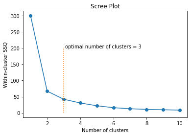

```python
plt.plot(range(1,11), ssq, marker='o')
plt.xlabel("Number of clusters")
plt.ylabel("Within-cluster SSQ")
plt.title("Scree Plot")
#plt.show() #after seeing plotting we can notice at 3 we can notice rapid change and ssq of 3 is less than 2
plt.plot([3]*200, range(1,201), ":") #(xth position* yth position , range of dotted lines)
plt.text(3.1, 201, "optimal number of clusters = 3") # 3.1 and 201 plotting is position of text.
# How to find cluster number? SSQ should be less and rapid change should be notice.
plt.show()
```

From the result we see that three should be the optimal number of clusters for the given data

Let's fit the KMeans model again with K=3

```python
my_model = KMeans(n_clusters=3, random_state=123)
```

```python
result= my_model.fit(df_scaled)
```

# 4) Test the Model

```python
predictions = result.predict(df_scaled)
```

```python
predictions[:5] # shows records from start upto 5th index.
#type(predictions[:5])
```

```
array([1, 2, 1, 2, 0])
```

# 5) Deploy the Model

```python
# new obesrvation
pred_new = list(result.predict([[9.3,5.36]]))
pred_new
```

```
[1]
```

```python
predictions # all
```

```
array([1, 2, 1, 2, 0, 2, 1, 0, 2, 1, 2, 2, 0, 2, 1, 0, 1, 2, 1, 2, 2, 0,
       0, 2, 0, 2, 2, 1, 2, 0, 2, 0, 1, 0, 2, 2, 2, 1, 2, 1, 1, 1, 0, 2,
       2, 2, 0, 1, 1, 1, 1, 2, 1, 0, 1, 2, 0, 1, 0, 1, 2, 1, 0, 2, 1, 0,
       0, 1, 0, 2, 2, 1, 0, 0, 2, 1, 2, 2, 0, 2, 0, 0, 1, 1, 2, 1, 0, 2,
       2, 0, 0, 2, 0, 1, 0, 1, 0, 2, 2, 0, 2, 1, 0, 0, 0, 2, 1, 0, 2, 0,
       2, 1, 2, 0, 1, 0, 0, 1, 2, 0, 0, 0, 0, 1, 1, 0, 2, 1, 2, 2, 2, 1,
       1, 1, 1, 2, 1, 1, 0, 0, 1, 0, 1, 2, 1, 0, 1, 1, 2, 0])
```

```python
# Now 1st record belongs to cluster 1, 2nd record belongs to cluster 2,... 5th belongs to cluster 0
```

Plot the data partitioned into clusters.

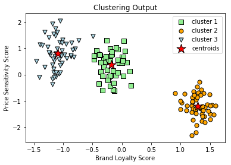

```python
                                # cluster,column0                #cluster,column1     #s=size,c=color
plt.scatter(df_scaled[predictions==0,0], df_scaled[predictions==0, 1], s=50, c='lightgreen',\
           marker='s', edgecolors='black', label='cluster 1')
plt.scatter(df_scaled[predictions==1,0], df_scaled[predictions==1, 1], s=50, c='orange',\
           marker='o', edgecolors='black', label='cluster 2')
plt.scatter(df_scaled[predictions==2,0], df_scaled[predictions==2, 1], s=50, c='lightblue',\
           marker='v', edgecolors='black', label='cluster 3')
plt.scatter(result.cluster_centers_[:,0], result.cluster_centers_[:,1], s=250, c='red',\
           marker='*', edgecolors='black', label='centroids')
plt.legend(scatterpoints=1) # it will show symbols i.e.square, triangle,circle 1 time
plt.xlabel("Brand Loyalty Score")
plt.ylabel("Price Sensitivity Score")
plt.title("Clustering Output")
plt.show()
```

Interpreting Clustering output requires domain knowledge. For example, we could interpret the three clusters seen above as (From left to right):

```
Cluster 3: Group of customers with least brand loyality points and highest senstivity to product pricings.
Cluster 1: Group of customers that have moderate Brand loyality but are relatively more sensitive to product pricing.
Cluster 2: Group of customers that are highly loyal to the brand and their purcahsing behaviour is least sensitive to price.
```

Accordingly, an analyst may conclude following labels for each cluster:

```
Cluster 3: Loyal to low cost
Cluster 1: Value Conscious
Cluster 2: Brand Advocates
```

We can insert these labels back into our dataset.

```python
predictions_relabelled = np.where(predictions==0, "Value Conscious", np.where(predictions==1,\
                                                                                    "Brand Advocates", "Loyal to low cost"))
df['category'] = pd.Series(predictions_relabelled, index=df.index)
df.index.name = "Customer Number"
```

```python
pd.DataFrame(df).head()
```

| Customer Number | brand_loyality_score | price_sensitivity_score | category |
| --- | --- | --- | --- |
| 0 | 9.310463 | 5.356477 | Brand Advocates |
| 1 | 1.887756 | 7.301291 | Loyal to low cost |
| 2 | 9.554102 | 5.339255 | Brand Advocates |
| 3 | 1.239190 | 7.775585 | Loyal to low cost |
| 4 | 4.042612 | 6.993620 | Value Conscious |

```python
df.to_csv("marketing_segementation_output.csv", index=False)
```